# Mobility and Transportation model

Roletto Enrico

19/May/2018

# Invidivual Project for the course in Smart City and IoT @MADAS 2017/2018

For the project we need these libraries

```r
library(data.table)
library(igraph)
library(stringr)
library(readxl)
```

## Data preparation and cleaning

Loading the data from the excel spreedsheet

```r
datamap <- as.data.table(read_excel("Transportmodeling.xlsx",
                           sheet = "DATAMAP"))
network <- as.data.table(read_excel("Transportmodeling.xlsx",
                      sheet = "NETWORK"))
coord <- as.data.table(read_excel("Transportmodeling.xlsx",
                      sheet = "COORD"))
speedFlow <- as.data.table(read_excel("Transportmodeling.xlsx",
                    sheet = "SPEED-FLOW"))
matOD <- as.data.table(read_excel("Transportmodeling.xlsx",
                                      sheet = "MAT_OD"))
```

Let’s have a look at the speed flow table.

In this table we have the percetange reduction in speed given a capacity index and a load level (number of vehicles on the road over the capacity). We will reshape these data in order to use them easely later:

- we change the shape from wide to long
- we create two columns representing the inferior and superior limit for each range (for the highest load limit We use an extreme high value, to be sure all observations will fall inside our range).

```r
head(speedFlow)
```

| CAP_INDEX | SPEED_20 | SPEED_40 | SPEED_60 | SPEED_80 | SPEED_90 |
| --- | --- | --- | --- | --- | --- |
| 1 | 0 | 0 | 0 | 0 | 0 |
| 4 | 30 | 65 | 75 | 85 | 90 |
| 5 | 25 | 60 | 70 | 80 | 85 |
| 6 | 20 | 50 | 60 | 70 | 80 |
| 7 | 15 | 40 | 50 | 60 | 70 |
| 8 | 10 | 30 | 40 | 50 | 60 |

```r
speedFlow[, SPEED_0:=0]
speedFlow<- melt(speedFlow, id=1, measure.vars = c(2:7),
                 variable.name = 'load_left', value.name = 'speed_red')[,
            load_left := as.numeric(str_extract(load_left, "([0-9])"))/10]
setorder(speedFlow, CAP_INDEX, load_left)
speedFlow[, load_right:=shift(load_left,1, type = 'lead'), by=CAP_INDEX]
speedFlow[is.na(speedFlow)]<- 10
head(speedFlow, 3)
```

| CAP_INDEX | load_left | speed_red | load_right |
| --- | --- | --- | --- |
| 1 | 0.0 | 0 | 0.2 |
| 1 | 0.2 | 0 | 0.4 |
| 1 | 0.4 | 0 | 0.6 |

```r
tail(speedFlow, 3)
```

| CAP_INDEX | load_left | speed_red | load_right |
| --- | --- | --- | --- |
| 8 | 0.6 | 40 | 0.8 |
| 8 | 0.8 | 50 | 0.9 |
| 8 | 0.9 | 60 | 10.0 |

Let’s have now a look at the origin destination matrix

- We remove the duplicated rows, adding up the vehicles between duplicates
- We create 3 new columns, each one with the number of vehicles according to the incremental rule: 50% - 30% - 20% (of the total).

```r
sum(duplicated(matOD[,.(ZONE_O, ZONE_D)]))
```

```
[1] 125
```

```r
matOD <- matOD[ZONE_O!=ZONE_D, .(VEH_H=sum(VEH_H)), by=c('ZONE_O', 'ZONE_D')]
matOD[, c('VEH_50', 'VEH_30', 'VEH_20'):= .(ceiling(VEH_H*0.5), round(VEH_H*0.3), VEH_H - round(VEH_H*0.3) - ceiling(VEH_H*0.5))]
```

```r
table(network$DIR_CODE)
```

```
  0   1
380 526
```

```r
names(network) <- gsub(x = names(network),
                        pattern = "-",
                        replacement = "_")
#subset two way links
network_2way = network[DIR_CODE==0, .(A_NODE=B_NODE, B_NODE=A_NODE, DIST,   LINK_TYPE=LINK_TYPE_B_A,
                       CAP_INDEX=CAP_INDEX_B_A,
                       SPEED=SPEED_B_A, CAPACITY=CAPACITY_B_A, DIR_CODE)]
network[, c('LINK_TYPE_B_A', 'CAP_INDEX_B_A', 'SPEED_B_A', 'CAPACITY_B_A'):=NULL]
names(network)<- c("A_NODE", "B_NODE", "DIST", "LINK_TYPE", "CAP_INDEX",
                   "SPEED",     "CAPACITY",  "DIR_CODE")
network_complete <- rbind(network, network_2way)
```

Further data cleaning:

- We drop in the `coord` table the vertices that are not in the network
- We impute the coordinates of the vertex `375` that are missing
- there are two edges with 0 capacity (they should have capacity `= 999999`)
- We create some new variables (`'LOAD', 'VLOAD', 'TIME_min'`) that We will use later

```r
#drop vertex without links
net_vertexlist = c(network_complete$A_NODE,network_complete$B_NODE)
coord_complete = coord[(NODE %in% net_vertexlist),]
# node 375 is missing from coord table
# node 375 has links with only two other real point
cord375E = colMeans(coord[NODE %in% c(643, 2680), .(COORD_X, COORD_Y)])
coord_complete = rbind(coord_complete,
                data.frame("NODE" = 375, "COORD_X" = cord375E[1], "COORD_Y" = cord375E[2], "NAME" = NA))
rm(coord, network, network_2way)
names(coord_complete)<- c("NODE", "x", "y", "NAME")
network_complete[, c('LOAD', 'VLOAD', 'TIME_min') := list(0, 0, (DIST/SPEED)*60) ]
# the are two edges with 0 capacity (they should have capacity 999999)
network_complete[CAPACITY==0, CAPACITY:=999999]
#I create a var to keep the ordering of the network edgelist
network_complete[, order:=.I]
```

## Load the network in `igraph`

here we load the network as an `igraph` object and plot it. The zones apper to be immaginary nodes (some of them are very far away from the others), but we will keep them as they are.

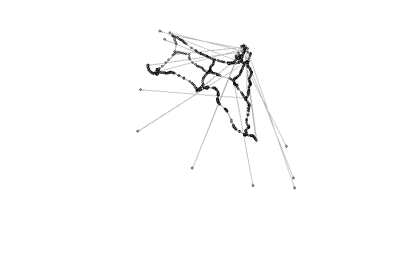

```r
tr_net<-graph_from_data_frame(vertices = coord_complete, d= network_complete, directed = TRUE)
plot.igraph(tr_net,
            vertex.color=adjustcolor("gray",alpha.f=0.5), vertex.size=3, vertex.label=NA,
            link=adjustcolor("red",alpha.f=0.5), edge.width=1,
            edge.arrow.size=.1)
```

## Assignment model

Using few loops we build the assignment model. - We build the minimum spanning tree using the `igraph` function `shortest_paths`; `shortest_paths` uses Dijkstra’s algorithm for weighted graphs, see [here](http://igraph.org/r/doc/distances.html)) - We Assign incrementally the vehicles according to the following rule: 50% - 30% - 20% - We Update the link travel times with flow/capacity given the data in the `speed_flow` table.

There are 3 nested loops:

- one on the columns `('VEH_50', 'VEH_30', 'VEH_20')` of the `matOD`.
- one on each origin (More precisely we loop on `unique(matOD$ZONE_O`, because some zones are not among the origins), where we calculate the shortest_path to all the destionations
- one on the shortest_path returned by the function `shortest_paths`, where for each edge in the shortest path We assign the number of vehicles given by the columns`('VEH_50', 'VEH_30', 'VEH_20')`

To update the speed We join the network table with the speedFlow table We created before. Specifically we perform a non-equi join (also called “interval joins”, that perform a match on a range of values) with `data.table` rolling joins.

```r
E(tr_net)$VLOAD <- 0
# First loop
for (cap in c('VEH_50', 'VEH_30', 'VEH_20')){
print(paste0('Iteration on column: ',cap))
# Second loop
for (orig in unique(matOD$ZONE_O)){
short_path <- shortest_paths(tr_net, orig,
                             to = matOD[ZONE_O==orig,]$ZONE_D, mode = 'out',
                               weights = E(tr_net)$TIME_min, output = "both")
# Third loop
for (i in 1:length(short_path$epath)){
  E(tr_net, path=as.numeric(unlist(short_path$vpath[[i]])))$VLOAD <-
    (E(tr_net, path=unlist(short_path$vpath[[i]]))$VLOAD + matOD[ZONE_O==orig, get(cap)][i])

# End Third loop
}
# End Second loop
}
#Retrive the vehicles, calculate the load and update speed
network_complete$VLOAD<- E(tr_net)$VLOAD
network_complete[, LOAD:= VLOAD / CAPACITY]
# i join the network with the speedflow table to update the speed
network_complete <- network_complete[speedFlow, .(A_NODE, B_NODE, DIST, LINK_TYPE, CAP_INDEX,
                              CAPACITY, DIR_CODE, LOAD, VLOAD, TIME_min, SPEED,

                              SPEED_updated = SPEED *(1 - speed_red/100)
                              , order),
                 on=.(CAP_INDEX, LOAD>=load_left, LOAD<=load_right),  nomatch=0]
#sort the data
setorder(network_complete, order)
# update the speed/time in the network
network_complete[, TIME_min:=(DIST/SPEED_updated)*60]
E(tr_net)$SPEED <- network_complete$SPEED_updated
E(tr_net)$TIME_min <- network_complete$TIME_min
# End First loop
}
```

```
[1] "Iteration on column: VEH_50"
[1] "Iteration on column: VEH_30"
[1] "Iteration on column: VEH_20"
```

## Output

Below, we plot the loaded network.

```r
E(tr_net)$width<- (3 + network_complete$LOAD*10)
E(tr_net)$color<-  as.factor((1 + network_complete$LOAD))
library(RColorBrewer)
#PLOT
pal = brewer.pal( n=6 , 'YlOrBr')[2:6]
V(tr_net)$size = 1
V(tr_net)[1:17]$size = 3
V(tr_net)[1:17]$color = 'blue'
```

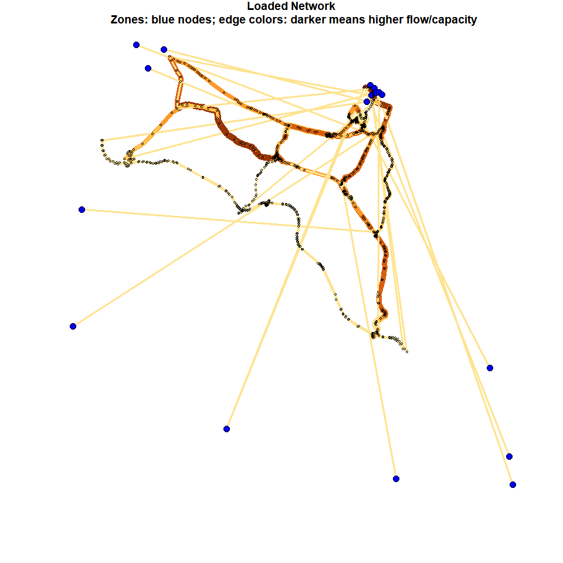

```r
plot.igraph(tr_net, vertex.label=NA,
            link=adjustcolor("red",alpha=0.5), edge.alpha = .5,
            edge.arrow.size=.02, palette=pal, edge.arrow.color='grey')
title("Loaded Network \n Zones: blue nodes; edge colors: darker means higher flow/capacity")
```